# Programming assignment 1

This is the data-analysis for programming assignment 1 using data from a personal activity monitoring device. This device collects data at 5 minute intervals through out the day. The data consists of two months of data from an anonymous individual collected during the months of October and November, 2012 and include the number of steps taken in 5 minute intervals each day.

Step 1:load the necessary libraries and the data

```r
library(plyr)
library(dplyr)
library(lubridate)
library(Hmisc)
```

```r
setwd("C:/Rwork/Activity")
fileurl<-"https://d396qusza40orc.cloudfront.net/repdata%2Fdata%2Factivity.zip"
filename<-"act.zip"
if(!file.exists(filename)){download.file(fileurl, filename)}
if(!file.exists("Activity.csv")){unzip(filename)}
datatabel<-read.csv("Activity.csv", header=TRUE, sep=",", na.strings = "NA")
## convert the column "date" to date-type
datatabel$date<-as.Date(datatabel$date, format="%Y-%m-%d")
## convert interval to time
temp<-mapply(function(x, y) paste0(rep(x, y), collapse = ""), 0, 4 - nchar(datatabel$interval))
datatabel$interval<-paste0(temp, datatabel$interval)
datatabel$interval<-paste(datatabel$interval,"00", sep="")
```

What is mean total number of steps taken per day?  
Histogram of the total number of steps taken each day

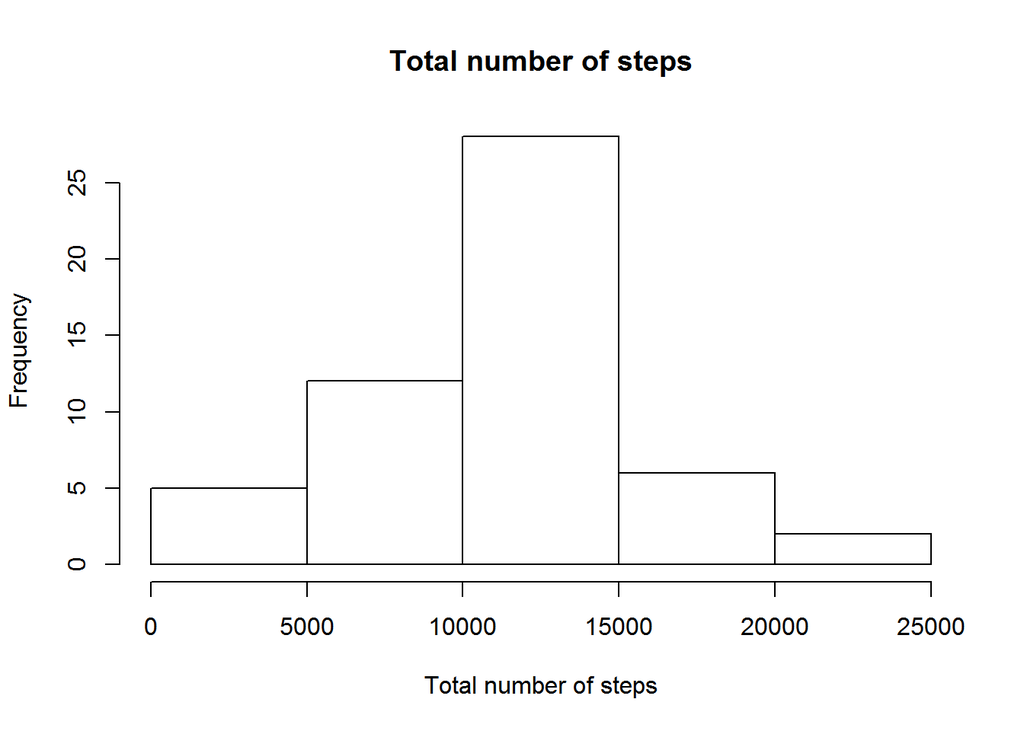

```r
datatabelcl<-na.omit(datatabel)
sumtabelcl<-aggregate(x=datatabelcl["steps"], FUN=sum, by=list(datatabelcl$date))
colnames(sumtabelcl)<-c("Date", "steps")
hist(sumtabelcl$steps, xlab = "Total number of steps", main="Total number of steps")
```

```r
mean(sumtabelcl$steps)
```

```
## [1] 10766.19
```

```r
median(sumtabelcl$steps)
```

```
## [1] 10765
```

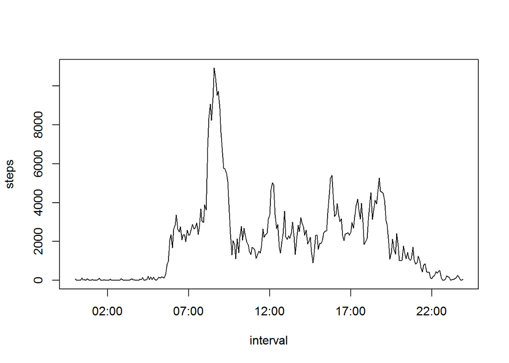

```r
## group steps per interval
sumtabelcl2<-aggregate(x=datatabelcl["steps"], FUN=sum, by=list(datatabelcl$interval))
colnames(sumtabelcl2)<-c("interval", "steps")
## convert interval to time
sumtabelcl2$interval<-parse_date_time(sumtabelcl2$interval, "HMS")
plot(steps~interval,sumtabelcl2, type="l")
```

```r
##retrieve interval containing the maximum number of steps on average across all days
format(sumtabelcl2[which.max(sumtabelcl2$steps),]$interval, format="%H%M")
```

```
## [1] "0835"
```

Imputing missing values  
Missing values: the strategy used is by imputing the mean of steps by interval

```r
## total number of missing values in the dataset
sum(is.na(datatabel))
```

```
## [1] 2304
```

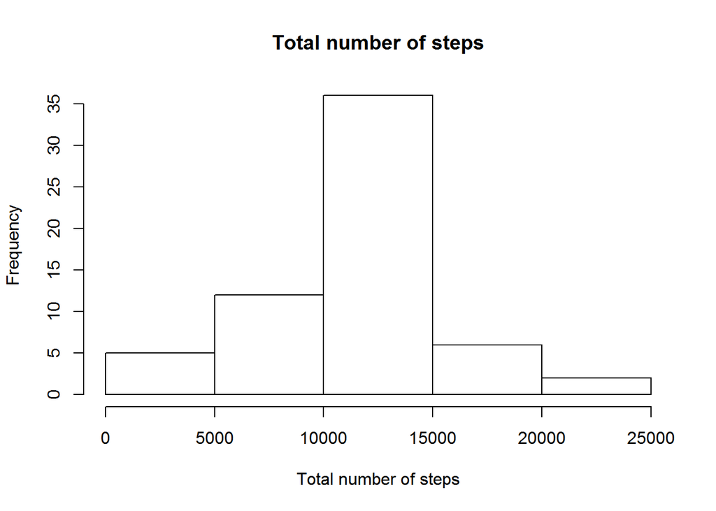

```r
##Missing values are filled in using impute mean of steps by interval
datatabelfilled<-ddply(datatabel, "interval", mutate, steps=impute(steps, mean))
## summarise datatabelfilled by date
sumtabelfilled<-aggregate(x=datatabelfilled["steps"], FUN=sum, by=list(datatabelfilled$date))
##reset colnames
colnames(sumtabelfilled)<-c("interval","steps")
## histogram total numbers of steps per day
hist(sumtabelfilled$steps, xlab = "Total number of steps", main="Total number of steps")
```

```r
mean(sumtabelfilled$steps)
```

```
## [1] 10766.19
```

```r
median(sumtabelfilled$steps)
```

```
## [1] 10766.19
```

The result of imputing missing values using the mean of the steps results in the fact that the mean and the median become equal.

Are there differences in activity patterns between weekdays and weekends?

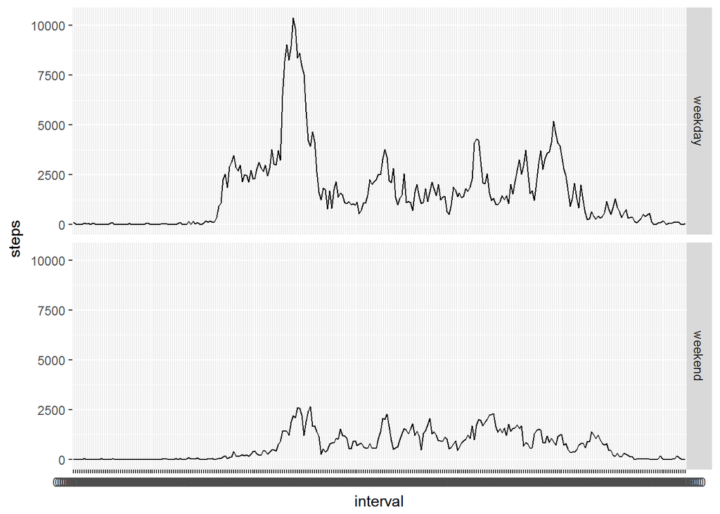

```r
## create weekend vector
weekend<-c("zaterdag", "zondag")
## add $weekend column containig weekday or weekend
datatabelfilled$weekend<-c('weekday', 'weekend')[(weekdays(datatabelfilled$date) %in% weekend)+1L]
## summarize per interval split by weekend/weekday
sumtabelfilledintwek<-aggregate(x=datatabelfilled["steps"], FUN=sum, by=list(datatabelfilled$interval, datatabelfilled$weekend))
colnames(sumtabelfilledintwek)<-c("interval","weekwork", "steps")
sumtabelfilledintwek$weekwork<-as.factor(sumtabelfilledintwek$weekwork)
g<-ggplot(sumtabelfilledintwek, aes(interval, steps, group=1))
g+geom_line()+facet_grid(weekwork~.)
```